# PolyBailout_Script

Pooja Pednekar

2026-05-22

As of 05/22/2026 this script plots pH, Temperature and Conductivity data from the APEX loggers. This script also plots PreSens Oxy data which is used for the first time to include in Polyp bailout experiments. Additionally, there is a PAM plot included in this script which gives us the background on the photosynthetic ability of the corals.

This script plots Polyp Bailout measurements for the Putnam lab and is based on the Putnam Lab Script available here: https://github.com/Putnam-Lab/CBLS_Wetlab/tree/main/Scripts/daily-measurements.Rmd

For APEX data, the script is based on Zoe Dellart’s Protocolhttps://github.com/zdellaert/TimeSeries/blob/main/protocols/Apex_Download.md and script https://github.com/zdellaert/TimeSeries/blob/main/3-Pacu/code/DMs.Rmd.

##APEX DATA conversion

```r
#exported apex data online
#1. Export data
#2.Open xml file in excel
#3. Save as csv
#4. Importing csv into R


#reading file
apex <- read.csv("C:/PUTNAM LAB/Pacuta_Polyp_Bailout/data/ApexLogger/Spring_2026/20260422Trail1/ApexRawData.csv", sep=",", skip=c(1), header=TRUE, na.strings = "NA")[6:9]

#Selecting column names of our desire
colnames(apex) <-  c("DateTime","ProbeName","ProbeType","Value")

head(apex)
```

```
##              DateTime    ProbeName ProbeType Value
## 1 04/21/2026 00:00:00  Light1_9_1A      Amps     0
## 2 04/21/2026 00:00:00  Light2_9_2A      Amps     0
## 3 04/21/2026 00:00:00 RetPump_9_3A      Amps     0
## 4 04/21/2026 00:00:00  Heater_9_4A      Amps     0
## 5 04/21/2026 00:00:00 Skimmer_9_5A      Amps     0
## 6 04/21/2026 00:00:00    Pump_9_6A      Amps     0
```

```r
#converting date and adapting to the timezone
apex$DateTimeHST <- parse_date_time(apex$DateTime, "%m/%d/%y %H:%M:%S", tz = "Pacific/Honolulu")
apex$DateTimeEST <- with_tz(apex$DateTimeHST, tzone = "America/New_York")
head(apex)
```

```
##              DateTime    ProbeName ProbeType Value DateTimeHST
## 1 04/21/2026 00:00:00  Light1_9_1A      Amps     0  2026-04-21
## 2 04/21/2026 00:00:00  Light2_9_2A      Amps     0  2026-04-21
## 3 04/21/2026 00:00:00 RetPump_9_3A      Amps     0  2026-04-21
## 4 04/21/2026 00:00:00  Heater_9_4A      Amps     0  2026-04-21
## 5 04/21/2026 00:00:00 Skimmer_9_5A      Amps     0  2026-04-21
## 6 04/21/2026 00:00:00    Pump_9_6A      Amps     0  2026-04-21
##           DateTimeEST
## 1 2026-04-21 06:00:00
## 2 2026-04-21 06:00:00
## 3 2026-04-21 06:00:00
## 4 2026-04-21 06:00:00
## 5 2026-04-21 06:00:00
## 6 2026-04-21 06:00:00
```

```r
# filtering dates based on experiment timeline  (use GMT for the time, so +6)
apex_Exp <- apex %>% filter(DateTimeEST >= "2026-04-22 11:00:00" & DateTimeEST <= "2026-04-23 11:00:00")

#unique(apex_Exp$ProbeType) #checking the probetype names

1.00#filtering data to be plotted  filter(!(ProbeType == "Cond" & Value %in% c(0, 0.1)))
```

```
## [1] 1
```

```r
apex_toplot <- apex_Exp %>%
  filter(ProbeType == "Temp"|
         ProbeType == "pH"|
         ProbeType == "Cond") %>%
  filter(!(ProbeType == "Cond" & Value <= 0.2)) %>%
  mutate(Value = ifelse(ProbeType == "Cond",round(Value * 0.64, 1), Value))
```

## APEX plots

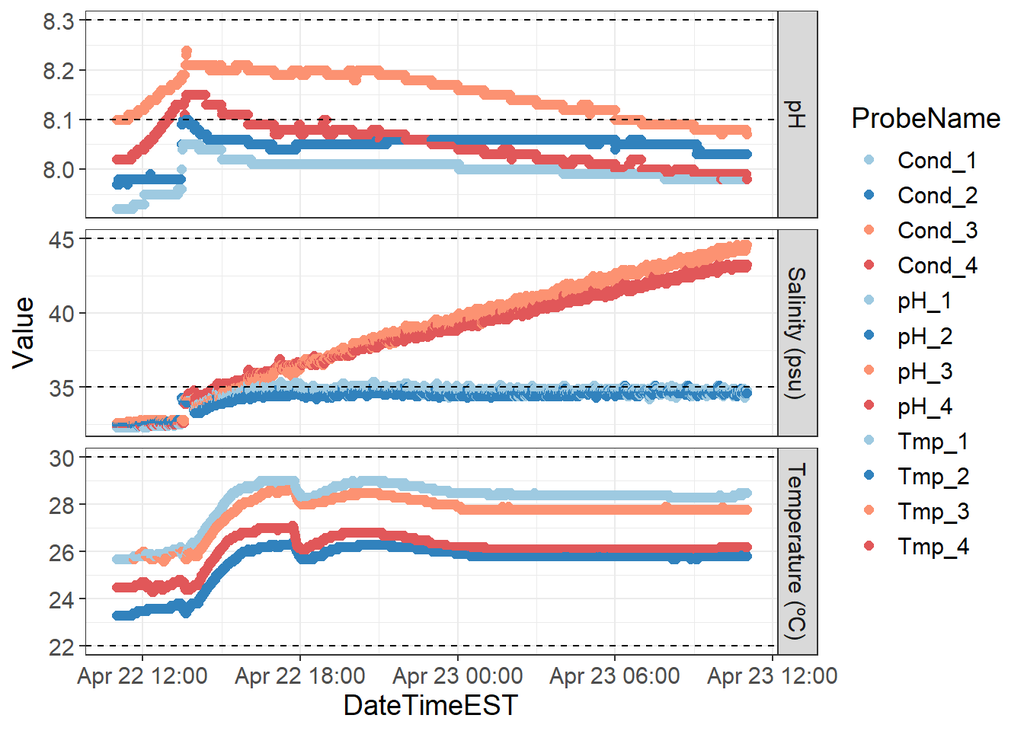

```r
# Threshold lines
hlines_data <- data.frame(yintercept = c(22.0, 30.0,35.0, 45.0,8.1, 8.3),
  ProbeType = c("Temp", "Temp", "Cond", "Cond","pH", "pH"))

facet_labels <- unique(apex_Exp$ProbeType)
names(facet_labels) = facet_labels
facet_labels <- replace(facet_labels, which(facet_labels == "pH"), "pH")
facet_labels <- replace(facet_labels, which(facet_labels == "Cond"), "Salinity (psu)")
facet_labels <- replace(facet_labels, which(facet_labels == "Temp"), "Temperature (ºC)")

apex_final <- apex_toplot %>%
  ggplot(aes(x = DateTimeEST,
             y = Value,
             colour = ProbeName)) +
  geom_point(size = 2) +
  geom_hline(data = hlines_data,aes(yintercept = yintercept),linetype = "dashed",
    inherit.aes = FALSE
  ) +
  scale_color_manual(values = custom_colors) +
  xlab("DateTimeEST") +
  facet_grid(factor(ProbeType, c("pH", "Cond", "Temp")) ~ .,scales = "free_y",labeller = as_labeller(facet_labels)) +
  theme_bw() +
  theme(text = element_text(size = 14))
# Save plot
ggsave("../Output/Daily_Measurements.png", apex_final, width = 20, height = 15, units = c("in"))

apex_final
```

#OXY DATA

```r
#reading oxy files
Oxy1 <- read.csv("C:/PUTNAM LAB/Pacuta_Polyp_Bailout/data/PreSens_OxyData/20260422/20260422_B2_CH1.csv",
  fileEncoding = "latin1")
Oxy2 <- read.csv("C:/PUTNAM LAB/Pacuta_Polyp_Bailout/data/PreSens_OxyData/20260422/20260422_B4_CH2.csv",
  fileEncoding = "latin1")
Oxy3 <- read.csv("C:/PUTNAM LAB/Pacuta_Polyp_Bailout/data/PreSens_OxyData/20260422/20260422_A2_CH3.csv",
  fileEncoding = "latin1")
Oxy4 <- read.csv("C:/PUTNAM LAB/Pacuta_Polyp_Bailout/data/PreSens_OxyData/20260422/20260422_A4_CH5.csv",
  fileEncoding = "latin1")


#adding columns in the dataframes
Oxy1$Chamber <- "Oxy_1"
Oxy2$Chamber <- "Oxy_2"
Oxy3$Chamber <- "Oxy_3"
Oxy4$Chamber <- "Oxy_4"

# Combine into one dataframe
oxy_everything <- bind_rows(Oxy1, Oxy2, Oxy3, Oxy4)

#select columns needed for the analysis
oxy_final <- oxy_everything %>%
  select(Date, Oxygen, Chamber)%>%
 filter(!(Chamber == "Oxy_2" & Oxygen > 100))

# Convert datetime column
oxy_final$Date <- as.POSIXct(
  oxy_final$Date,
  format = "%d/%m/%y %H:%M:%S"
)

# Plot
oxy_plot <- ggplot(oxy_final,
       aes(x = Date,
           y = Oxygen,
           color = Chamber)) +
  geom_line(alpha = 0.7) +
  theme_classic() +
  labs(x = "Time",
       y = "Oxygen Concentration (µmol/L)",
       color = "Chamber")


# Save plot
ggsave("../Output/20260422/Oxygen_Trial1.png", oxy_plot, width = 10, height = 8, units = c("in"))
```

#PAM DATA

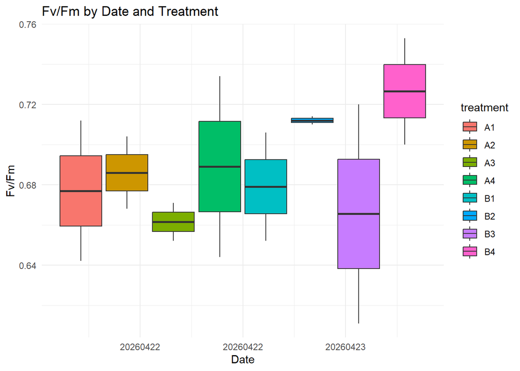

```r
PAM <- read.csv("C:/PUTNAM LAB/Pacuta_Polyp_Bailout/data/PAM/PAM.csv") %>% clean_names()
PAM <- PAM %>% mutate(Date = as.factor(date)) %>%
                mutate(Timepoint = factor(timepoint)) %>%
                mutate(Treatment = factor(treatment,levels = c("A1","A2","A3","A4","B1", "B2", "B3", "B4" , ordered=TRUE)))


ggplot(PAM,aes(x = date, y = fv_fm_y_1000)) +
    geom_boxplot(aes(fill = treatment)) + labs(x = "Date", y = "Fv/Fm", title = "Fv/Fm by Date and Treatment") +
  theme_minimal()
```

```r
ggsave("../output/PAM.png", plot = last_plot(), width = 9, height = 4, bg = "white")
```

apex_Temp <- apex_Exp %>% filter(ProbeType == “Tmp”)

apex_Temp %>% ggplot(aes(x = DateTimeEST, y = Value, color = ProbeName)) + geom_line(linewidth = 0.3, alpha = 0.4) + geom_smooth(se = FALSE, linewidth = 1) + facet_wrap(~ProbeName, ncol = 2) + labs( x = “Date Time”, y = “Temperature (°C)”, title = “Temperature Over Time” ) + theme_bw() + theme( panel.grid.minor = element_blank(), strip.background = element_rect(fill = “grey90”), legend.position = “none” )

```
#Make a list of dataframes, each containing a horizontal line that will correspond to the upper and lower threshold of each parameter (temperature, salinity, pH total)
hlines_data <- list(
  data.frame(yintercept = 22.0, metric = "Temp"), # lower threshold for temperature in C°
  data.frame(yintercept = 30.0, metric = "Temp"), # upper threshold for temperature in C°
  data.frame(yintercept = 33.0, metric = "Cond"), # lower threshold for salinity in psu
  data.frame(yintercept = 70.0, metric = "Cond"), # upper threshold for salinity in psu
  data.frame(yintercept = 7.5, metric = "pH"), # lower threshold for total pH
  data.frame(yintercept = 8.4, metric = "pH") # upper threshold for total pH
   )

#creating facet labels for the individual facets
facet_labels <- unique(apex_Exp$ProbeType)
names(facet_labels) = facet_labels
facet_labels <- replace(facet_labels, which(facet_labels == "pH"), "pH")
facet_labels <- replace(facet_labels, which(facet_labels == "Cond"), "Salinity (psu)")
facet_labels <- replace(facet_labels, which(facet_labels == "Temp"), "Temperature (ºC)")

apex_final<-apex_toplot %>%
  ggplot(aes(x=DateTimeEST, y=Value, colour=ProbeName))+
  geom_point(size=2)+
  xlab("DateTimeEST")+
  facet_grid(factor(ProbeType,c("pH","Cond","Temp")) ~ ., scales = "free_y", labeller = as_labeller(facet_labels))+
  geom_hline(data = hlines_data[[1]], aes(yintercept = yintercept), linetype = "dashed") +
  geom_hline(data = hlines_data[[2]], aes(yintercept = yintercept), linetype = "dashed") +
  geom_hline(data = hlines_data[[3]], aes(yintercept = yintercept), linetype = "dashed") +
  geom_hline(data = hlines_data[[4]], aes(yintercept = yintercept), linetype = "dashed") +
  geom_hline(data = hlines_data[[5]], aes(yintercept = yintercept), linetype = "dashed") +
  geom_hline(data = hlines_data[[6]], aes(yintercept = yintercept), linetype = "dashed") +
  theme_bw() +
  theme(text = element_text(size = 14)); apex_final


# Save plot
ggsave("../Output/Daily_Measurements.pdf", apex_final, width = 20, height = 15, units = c("in"))
```

#exported apex data online #1. Export data #2.Open xml file in excel #3. Save as csv #4. Importing csv into R

#reading file apex <- read.csv(“C:/PUTNAM LAB/Pacuta_Polyp_Bailout/data/ApexLogger/Spring_2026/20260422Trail1/ApexRawData.csv”, sep=“,”, skip=c(1), header=TRUE, na.strings = “NA”)[6:9]

#Selecting column names of our desire colnames(apex) <- c(“DateTime”,“ProbeName”,“ProbeType”,“Value”)

head(apex)

#converting date and adapting to the timezone apex$DateTimeHST <- parse_date_time(apex$DateTime, “%m/%d/%y %H:%M:%S”, tz = “Pacific/Honolulu”) apex$DateTimeEST <- with_tz(apex$DateTimeHST, tzone = “America/New_York”) head(apex)

# filtering dates based on experiment timeline (use GMT for the time, so +6)

apex_Exp <- apex %>% filter(DateTimeEST >= “2026-04-22 11:00:00” & DateTimeEST <= “2026-04-23 11:00:00”)

1.00#filtering data to be plotted

apex_toplot <- apex_Exp %>% filter(ProbeType == “pH”, ProbeType == “Cond”, ProbeType == “Temp”)

#apex_pH <- apex_Exp %>% filter (ProbeType== “pH”) #apex_Cond <- apex_Exp %>% filter (ProbeType == “Cond”) #apex_temps <- apex_Exp %>% filter(ProbeType == “Temp”)

##Plot data

#logger_plot %>% ggplot()

## plotting extracted data

#apex_temps %>% ggplot(aes(x=DateTimeEST, y=Value, color = ProbeName)) + #geom_line(aes(color = ProbeName), size = 0.5) + #facet_grid(~ProbeType)+ #ylab(“Temperature (°C)”) +theme_minimal()